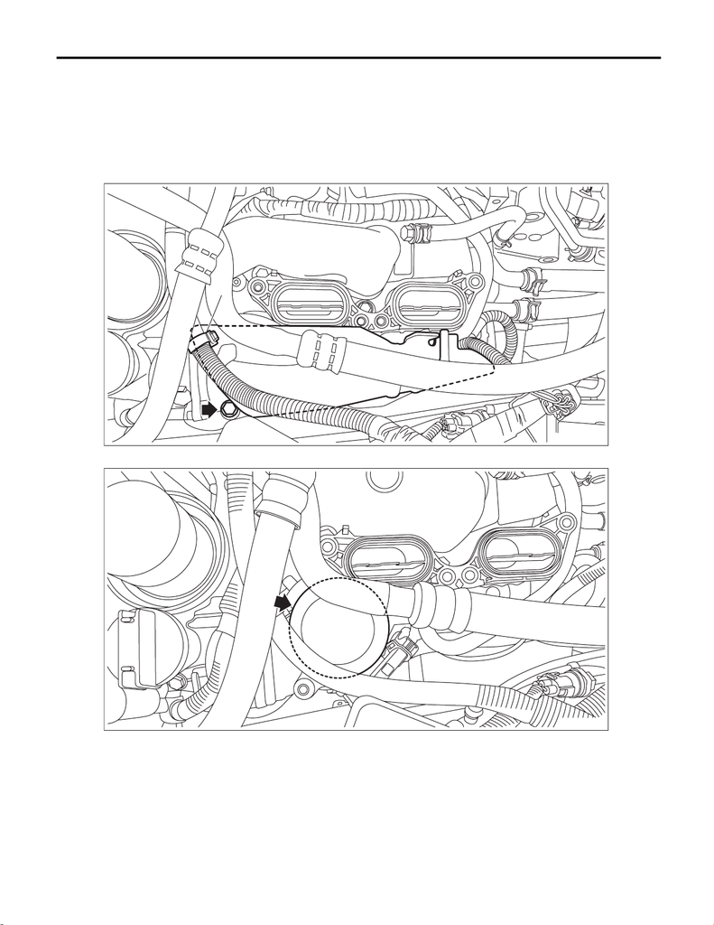

FU(w/o STI)-46

Fuel Insulator

FUEL INJECTION (FUEL SYSTEMS)

6. Fuel Insulator

A: REMOVAL

1. FUEL PUMP INSULATOR

1) Disconnect the ground terminal from battery sensor. <Ref. to NT-5, BATTERY, NOTE, Note.>

2) Remove the intake manifold. <Ref. to FU(w/o STI)-18, REMOVAL, Intake Manifold.>

3) Remove the clip (A) on the generator cord, and remove the fuel pipe protector.

4) Remove the fuel pump insulator.

FU-07785

(A)

FU-07786

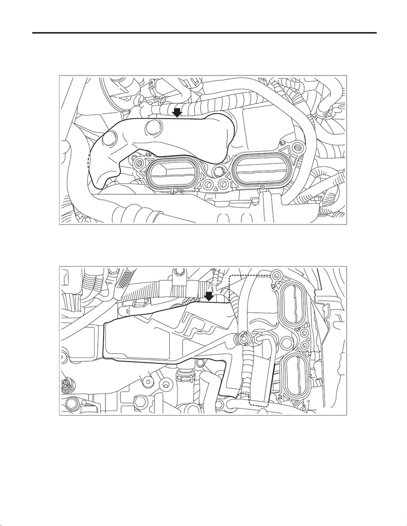

FU(w/o STI)-47

Fuel Insulator

FUEL INJECTION (FUEL SYSTEMS)

2. FUEL PIPE INSULATOR NO. 1

1) Disconnect the ground terminal from battery sensor. <Ref. to NT-5, BATTERY, NOTE, Note.>

2) Remove the intake manifold. <Ref. to FU(w/o STI)-18, REMOVAL, Intake Manifold.>

3) Remove the fuel pipe insulator No. 1.

3. FUEL PIPE INSULATOR NO. 2

1) Remove the fuel pipe insulator No. 1. <Ref. to FU(w/o STI)-47, FUEL PIPE INSULATOR NO. 1, REMOV-

AL, Fuel Insulator.>

2) Remove the fuel pipe insulator No. 2.

FU-07787

FU-07788

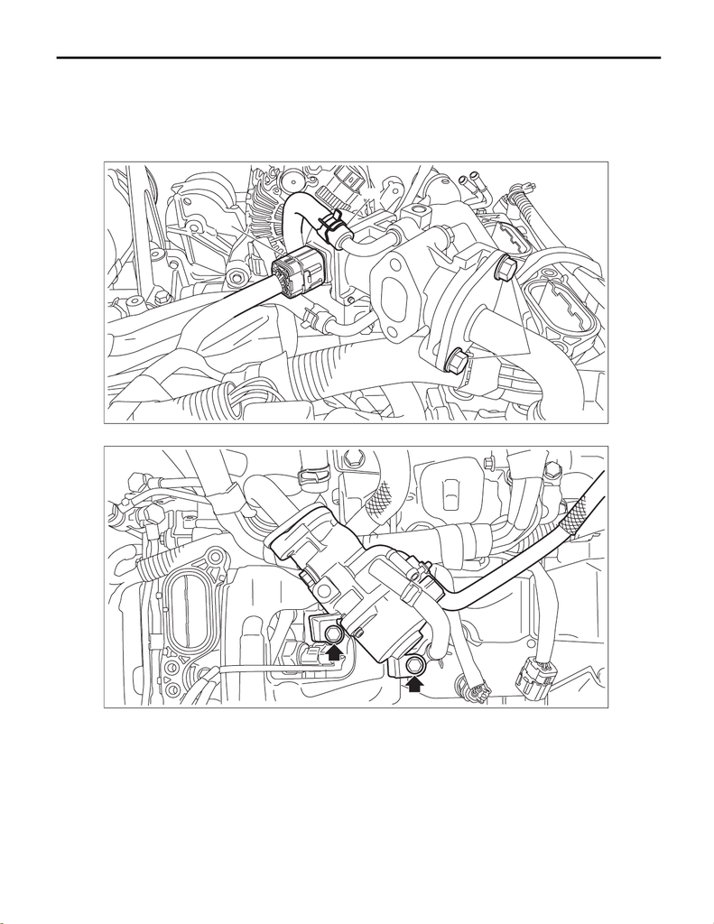

FU(w/o STI)-48

Fuel Insulator

FUEL INJECTION (FUEL SYSTEMS)

4. FUEL PIPE INSULATOR NO. 3

1) Disconnect the ground terminal from battery sensor. <Ref. to NT-5, BATTERY, NOTE, Note.>

2) Remove the intake manifold. <Ref. to FU(w/o STI)-18, REMOVAL, Intake Manifold.>

3) Disconnect the connector (A) from the EGR control valve.

4) Remove the bolts (B) securing the EGR cooler to the EGR control valve.

5) Remove the preheater hose (C) from the EGR control valve.

6) Remove the EGR control valve.

FU-07391

(A)

(B)

(C)

FU-07789

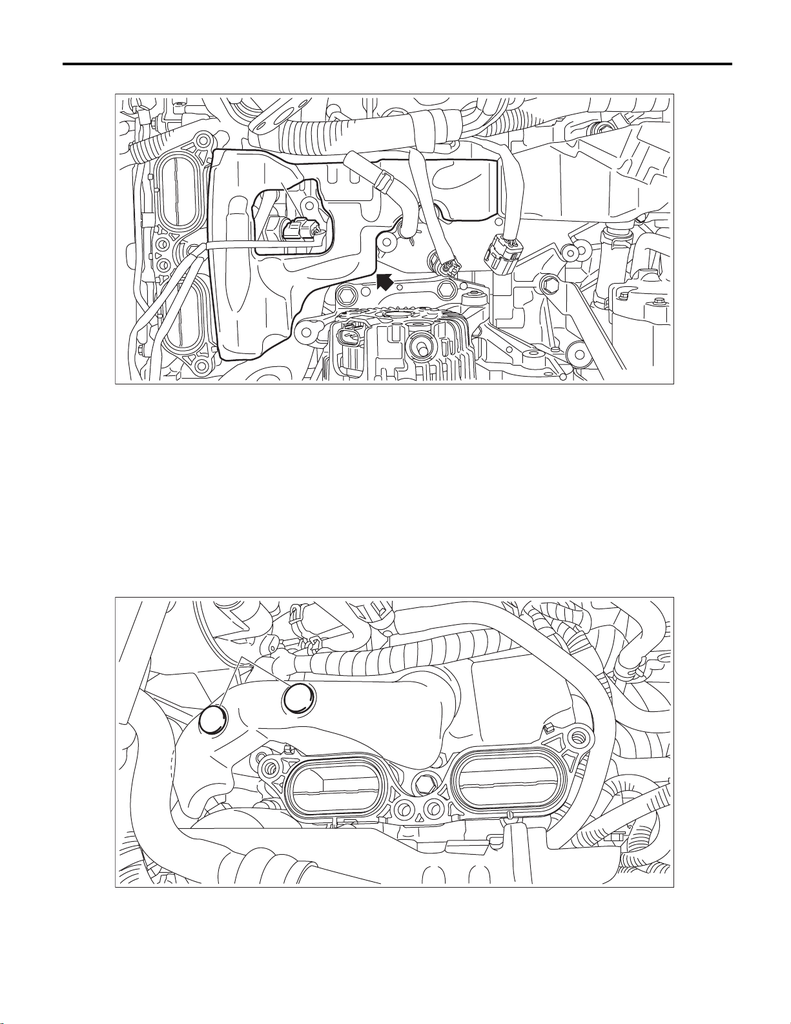

FU(w/o STI)-49

Fuel Insulator

FUEL INJECTION (FUEL SYSTEMS)

7) Disconnect the connector (A) on the fuel pressure sensor, and remove the fuel pipe insulator No. 3.

B: INSTALLATION

1. FUEL PUMP INSULATOR

Install in the reverse order of removal.

Tightening torque:

19 N·m (1.9 kgf-m, 14.0 ft-lb)

2. FUEL PIPE INSULATOR NO. 1

Install in the reverse order of removal.

NOTE:

When installing the fuel pipe insulator No. 1, push the sections (a) of fuel pipe insulator No. 1 to fix it to the

high-pressure fuel delivery pipe.

FU-07790

(A)

(a)

FU-07916

[figure not shown]

FU(w/o STI)-50

Fuel Insulator

FUEL INJECTION (FUEL SYSTEMS)

3. FUEL PIPE INSULATOR NO. 2

Install in the reverse order of removal.

4. FUEL PIPE INSULATOR NO. 3

Install in the reverse order of removal.

NOTE:

Use a new gasket.

Tightening torque:

19 N·m (1.9 kgf-m, 14.0 ft-lb)

C: INSPECTION

Check that the fuel insulator has no deformation, cracks or other damages.